# Spatial and Statistical Analysis of GEDI 2A data in R

**Author**: Hyeonmin Kang

**Institute**: EAGLE master, Julius-Maximilians-University Wuerzburg

**Email**: hyunminkang88@gmail.com

**Github**: https://github.com/YumYumYumi/MB2_EAGLE

**Operating system**: Ubuntu 20.04.4 LTS

**R version**: 4.2.0 (2022-04-22)

**Last Updated**: 12/05/2022

**Objective**: (1) demonstrating how to get the URL for downloading NASA’s Global Ecosystem Dynamics Investigation (GEDI) Data directly from the LP DAAC Data Pool, using NASA’s Common Metadata Repository (CMR). (2) visualizing and analyzing NASA’s Global Ecosystem Dynamics Investigation (GEDI) 2A Data spatially and statistically. (3) detecting the forest disturbance by processing GEDI 2A DATA.

**Additional Input Data Provider**: (1) https://land.copernicus.eu/pan-european/high-resolution-layers/forests (2) https://sentinel.esa.int/web/sentinel/user-guides/sentinel-2-msi/product-types/level-2a

## 1. Install and load required packages

```r
# install required packages (if not installed yet)
packagelist <- c("glue", "jsonlite","dplyr","ggplot2","ggthemes","raster","sf","tidyverse","devtools","rGEDI", "ggstatsplot", "sp","leaflet","leafsync","hdf5r","data.table","ggpubr")
new.packages <- packagelist[!(packagelist %in% installed.packages()[,"Package"])]
if(length(new.packages)) install.packages(new.packages)

# load required packages
lapply(packagelist, require, character.only = TRUE)

# If rGEDI is unavailable to install, use this development version of install line.
if ("rGEDI" %in% rownames(installed.packages()) == FALSE) {devtools::install_git("https://github.com/carlos-alberto-silva/rGEDI", dependencies = TRUE)}
```

### 2. Set up output directory and query parameter.

```r
#Set output dir for downloading the files
outdir <- getwd()
# set the bounding box
bbox <- "8.877,51.465,9.921,51.762" #lon_min, lat_min, lon_max, lat_max

# Set each value of the bounding box as one variable
xmin <- 8.877 #lon_min
xmax <- 9.9219 #lon_max
ymin <- 51.465 #lat_min
ymax <- 51.762 #lat_max

# name of GEDI data we need
# Here we need only GEDI2A data.
#GEDI1B <- 'GEDI01_B.002' # geolocation product
GEDI2A <- 'GEDI02_A.002' # Full-waveform product
#GEDI2B <- 'GEDI02_B.002' # Elevation and Height Metrics product

# dates that we are looking for
datetime_v <- c("2019.10.28", "2019.11.06", "2019.11.12", "2019.11.23", "2019.11.24")
```

### 3. Load polygons and raster data.

```r
# Import forest polygons as sf object
# Data Provider (1) Shapefile converted from forest type raster data inside of bounding box.
angiosperms <- sf::st_read("./data/forest1_vec_fixed.shp") # vector of broad-leaved forests
gymnosperms <- sf::st_read("./data/forest2_vec_fixed.shp") # vector of coniferous forests

# Combine two sf objects
forests <- rbind(angiosperms,gymnosperms)

# Data Provider (2) median NDVI (Normalized Difference Vegetation Index) image of Sentinel-2 (May to October, 2019)
ndvi_19 <- raster::brick("./data/2019s2_clipped_ndvi.tif")

# Above median NDVI is converted to shapefile and less than 0.5 NDVI values are extracted inside of forest area.
forest_disturbance <- sf::st_read("./data/ndvi19_disturbance_vec_0_fixed.shp")
```

This is my area of interest(AOI). South North Rhine-Westphalia and Lower Saxony, Germany.

```r
#plot my area of interest
leaflet() %>% addTiles() %>%
  addRectangles(
    lng1=xmin, lat1=ymin,
    lng2=xmax, lat2=ymax,
    fillColor = "transparent"
  )
```

[interactive chart not shown]

## 4. Download GEDI data URL

Here, we create a function to query CMR.

```r
# Currently, it is not available to download GEDI data directly from R and save it in the wished directory.
# So we have to get the URL and download it by ourselves.
# Get the URLs and use them to download the data
request_gedi_url <- function(product, bbox, datetime, print = TRUE) {
  # Define the base NASA's Common Metadata Repository (CMR) granule search URL,
  # including LPDAAC provider name and max page size (2000 is the max allowed)
  cmr <- "https://cmr.earthdata.nasa.gov/search/granules.json?pretty=true&provider=LPDAAC_ECS&page_size=2000&concept_id="
  # Create a vector where GEDI's version 2 data products and CMR Concept ID are saved.
  concept_ids <- c('GEDI01_B.002' = 'C1908344278-LPDAAC_ECS',
                   'GEDI02_A.002' = 'C1908348134-LPDAAC_ECS',
                   'GEDI02_B.002' = 'C1908350066-LPDAAC_ECS')
  # CMR uses pagination for queries with more features returned than the page size
  page <- "1"
  # Get CMR granule search endpoint with product concept ID, bbox & page number
  url <- glue::glue("{cmr}{concept_ids[product]}&bounding_box={bbox}&pageNum={page}")
  # Return the CMR granule as json
  cmr_json <- jsonlite::fromJSON(url)
  # Find the download links
  raw_links  <-  cmr_json$feed$entry$links
  # Search the download link for the date that we need.
  for (i in 1:length(raw_links)) {
    # href: an attribute of the anchor tag
    href <- raw_links[[i]]["href"][1,1]
    # Stop the loop when the date matches
    if (grepl(as.character(datetime), href, fixed = TRUE)){
      final_url <- href
      break
    }
  }
  # Set the conditional logical print argument.
  if (print == TRUE) {
    print(final_url)
    return(final_url)}
  if (print == FALSE) return(final_url)

}

# WARNING:: 1B and 2A data are bigger than 1 GB.
# I recommend using the data I already downloaded to protect your laptop space.
```

This is an example to show how to use the function. **WARNING: WE DO NOT NEED THIS DATA!**

```r
# Name of GEDI data we need
GEDI2B <- 'GEDI02_B.002'
# Set the date time (this is just an example datetime to show how to use the below function)
datetime_ex = "2019.11.02"
# Read GEDI level2B data (h5 file)
GEDI2B_url <- request_gedi_url(GEDI2B, bbox, datetime_ex, print = TRUE)
```

```
## [1] "https://e4ftl01.cr.usgs.gov//GEDI_L1_L2/GEDI/GEDI02_B.002/2019.11.02/GEDI02_B_2019306045019_O05035_03_T00152_02_003_01_V002.h5"
```

## 5. Read and clip GEDI data

Get URLs of downloading GEDI data using for loop. If you want, download the data by yourself and save it in your *outdir*. Next, use the option 1) code.

If you do not want to download all the GEDI data by yourself then skip option 1) and go to option 2)

**WARNING!! size of all GEDI data below are more than 10 GB. Check your storage space before you curse me.**

```r
for (d in datetime_v){
  request_gedi_url(GEDI2A, bbox, d, print = TRUE)
}
```

```
## [1] "https://e4ftl01.cr.usgs.gov//GEDI_L1_L2/GEDI/GEDI02_A.002/2019.10.28/GEDI02_A_2019301054234_O04958_02_T04405_02_003_01_V002.h5"
## [1] "https://e4ftl01.cr.usgs.gov//GEDI_L1_L2/GEDI/GEDI02_A.002/2019.11.06/GEDI02_A_2019310031246_O05096_03_T03610_02_003_01_V002.h5"
## [1] "https://e4ftl01.cr.usgs.gov//GEDI_L1_L2/GEDI/GEDI02_A.002/2019.11.12/GEDI02_A_2019316000058_O05187_02_T00182_02_003_01_V002.h5"
## [1] "https://e4ftl01.cr.usgs.gov//GEDI_L1_L2/GEDI/GEDI02_A.002/2019.11.23/GEDI02_A_2019327191055_O05370_02_T01712_02_003_01_V002.h5"
## [1] "https://e4ftl01.cr.usgs.gov//GEDI_L1_L2/GEDI/GEDI02_A.002/2019.11.24/GEDI02_A_2019328195621_O05386_03_T05385_02_003_01_V002.h5"
```

#### Option 1)

If you downloaded all the GEDI by yourself by using above code, please run the next code block. This for loop load the GEDI data you saved in your directory and clip it by bounding box. This might take more than 10 minutes, depending on your computer health and ability.

**WARNING!! size of all GEDI data below are more than 10 GB. Check your storage space before you curse me.**

```r
level2A_dt <- NULL # the dataframe to be filled
for (d in datetime_v){
  GEDI2A_link <-request_gedi_url(GEDI2A, bbox, d,print = FALSE)
  GEDI2A_filename <- tail(strsplit(GEDI2A_link, '/')[[1]], n = 1)
  gedilevel2a <-rGEDI::readLevel2A(level2Apath = paste0(outdir,"/",GEDI2A_filename))
  new_d <-gsub("\\.","_",d)
  GEDI2A_clip_name <-paste0(outdir,"/data/level2a_clip_bb_", new_d,".h5")
  level2a_clip_bb <- rGEDI::clipLevel2A(gedilevel2a, xmin, xmax, ymin, ymax, output=GEDI2A_clip_name)
  level2AM<-rGEDI::getLevel2AM(level2a_clip_bb)
  level2AM_filtered <- level2AM[level2AM$rh100 != 0, ]
  level2A_dt <- rbind(level2A_dt, level2AM_filtered)
}
```

#### Option 2)

```r
level2A_dt <- NULL # the dataframe to be filled

for (d in datetime_v){
  new_d <-gsub("\\.","_",d)
  GEDI2A_clip_name <-paste0(outdir,"/data/level2a_clip_bb_", new_d,".h5")
  gedilevel2a <-readLevel2A(level2Apath = GEDI2A_clip_name)
  level2AM<-getLevel2AM(gedilevel2a)
  level2AM_filtered <- level2AM[level2AM$rh100 != 0, ]
  level2A_dt <- rbind(level2A_dt, level2AM_filtered)
}
```

```r
head(level2A_dt[order(-level2A_dt$rh100), ],1)
```

```
##        beam       shot_number degrade_flag quality_flag delta_time sensitivity
## 1: BEAM0110 49580600200513394            0            0   57479234   0.9450589
##    solar_elevation lat_lowestmode lon_lowestmode elev_highestreturn
## 1:        1.723629       51.46766       9.443789           427.7563
##    elev_lowestmode   rh0  rh1   rh2   rh3   rh4   rh5  rh6  rh7  rh8  rh9 rh10
## 1:        300.9708 -2.01 -1.6 -1.23 -0.85 -0.56 -0.22 0.07 0.41 0.71 1.04 1.38
##    rh11 rh12 rh13 rh14 rh15 rh16 rh17 rh18 rh19 rh20 rh21 rh22 rh23 rh24 rh25
## 1: 1.71 2.05 2.39 2.69 2.95 3.21 3.47  3.7 3.92 4.15 4.37 4.59 4.78 5.01 5.19
##    rh26 rh27 rh28 rh29 rh30 rh31 rh32 rh33 rh34 rh35 rh36 rh37 rh38  rh39  rh40
## 1: 5.42  5.6 5.83 6.05 6.28  6.5 6.72 6.99 7.29 7.62 8.03 8.63 9.87 16.33 21.31
##     rh41 rh42  rh43  rh44 rh45 rh46  rh47  rh48  rh49  rh50  rh51  rh52  rh53
## 1: 29.64   32 36.86 40.75 44.6 49.5 53.24 55.29 57.54 64.19 67.67 71.59 74.55
##     rh54  rh55  rh56  rh57  rh58  rh59  rh60  rh61  rh62  rh63  rh64  rh65 rh66
## 1: 76.42 78.25 80.72 83.22 85.69 88.31 90.33 92.27 94.07 95.52 96.91 98.14 99.3
##      rh67   rh68  rh69   rh70   rh71   rh72   rh73   rh74   rh75   rh76   rh77
## 1: 100.42 101.43 102.4 103.56 104.83 105.88 106.89 107.86 108.76 109.62 110.44
##      rh78  rh79   rh80   rh81   rh82   rh83  rh84   rh85   rh86   rh87   rh88
## 1: 111.34 112.2 112.98 113.73 114.52 115.34 116.2 117.06 117.84 118.52 119.15
##      rh89   rh90   rh91   rh92   rh93   rh94  rh95  rh96   rh97   rh98   rh99
## 1: 119.71 120.31 120.91 121.51 122.14 122.74 123.3 123.9 124.54 125.25 125.96
##     rh100
## 1: 126.78
```

## 6. Intersect and visualize the data

Before intersecting the GEDI data by the polygon, convert them to sf object

```r
# Convert data table to data frame
level2A_df <- as.data.frame(level2A_dt)
# Transform the date frame as sf object
level2A_sf <- st_as_sf(level2A_df, coords = c("lon_lowestmode","lat_lowestmode"), remove = FALSE)
# Match the coordinate Reference System
st_crs(level2A_sf) <- st_crs(forests)
```

Create a function of intersect and use the function.

```r
intersect_f <- function(GEDI_point, polygon) {
  # Match the coordinate Reference System
  st_crs(GEDI_point) <- st_crs(polygon)
  # Intersect the GEDI points by a polygon
  intersected <- GEDI_point[st_intersects(GEDI_point, polygon) %>% lengths > 0,]
  return(intersected)
}

# Intersect the GEDI data by forest areas
level2A_forest <- intersect_f(level2A_sf, forests)
```

Subset forest GEDI data where quality flag 1 is. A quality flag value of 1 indicates the laser shot meets criteria based on energy, sensitivity, amplitude, and real-time surface tracking quality.

```r
level2A_forest_qf_1 <- level2A_forest[level2A_forest$quality_flag == 1, ]

# Intersect the GEDI data by forest disturbances
level2A_disturbance_qf_1<- intersect_f(level2A_forest_qf_1, forest_disturbance)
```

Visualize GEDI clipped data by leaflet (forest/disturbance GEDI data with quality flag = 1 data) When cursor is on the point, you can see the beam numbers. If the pulses are on the same line, they have same beam number.

```r
leaflet() %>% addTiles() %>%
  addCircleMarkers(level2A_forest$lon_lowestmode,
                   level2A_forest$lat_lowestmode,
                   radius = 1,
                   opacity = 1,
                   color = "green",
                   label = paste0("Beam number: ", level2A_forest$beam))  %>%
  addCircleMarkers(level2A_forest_qf_1$lon_lowestmode,
                   level2A_forest_qf_1$lat_lowestmode,
                   radius = 1,
                   opacity = 0.5,
                   color = "orange",
                   label = paste0("Beam number: ", level2A_forest_qf_1$beam))  %>%
  addCircleMarkers(level2A_disturbance_qf_1$lon_lowestmode,
                   level2A_disturbance_qf_1$lat_lowestmode,
                   radius = 1,
                   opacity = 0.9,
                   color = "cyan",
                   label = paste0("Beam number: ", level2A_disturbance_qf_1$beam))  %>%
  addScaleBar(options = list(imperial = FALSE)) %>%
  addProviderTiles(providers$Esri.WorldImagery)  %>%
  addLegend(colors = c("green","orange","cyan"),
            labels= c("All forest GEDI data" ,"qf = 1 forest GEDI","qf = 1 forest disturbance GEDI"),
            title ="GEDI LEVEL2A")
```

[interactive chart not shown]

Visualize GEDI quality flag 1 data with forest disturbance polygon using leaflet

```r
# clip forest disturbance polygon by bounding box of GEDI forest disturbance data
forest_disturbance_clipped <- st_crop(forest_disturbance, st_bbox(level2A_disturbance_qf_1))
```

```r
# This time, rh100 values will pop up if you click the points.
rh100_popup <- paste0("<strong>rh100: </strong>", level2A_disturbance_qf_1$rh100)

leaflet(level2A_disturbance_qf_1) %>%  addTiles() %>%
  addPolygons(data = forest_disturbance_clipped, # add forest disturbance polygon
              opacity = 0.7,
              smoothFactor = 0.5,
              color = "white")  %>%
  addCircleMarkers(~lon_lowestmode, # add GEDI pulse data
                   ~lat_lowestmode,
                   fillColor = "cyan",
                   fillOpacity = 0.8,
                   radius = 3,
                   stroke = F,
                   popup = rh100_popup)  %>%
  addProviderTiles(providers$Esri.WorldImagery) %>%
  addLegend("bottomright",  # location of legend
            colors = c("white","cyan"),
            labels= c("disturbance area", "GEDI pulses")
            )
```

[interactive chart not shown]

## 7. Plot RH Metrics Transects

### Background information of GEDI L2A DATA

The GEDI L2A data product provides relative height (RH) metrics, which are “lidar perceived” metrics. The RH metrics are intended for vegetated surfaces. So it results over bare/water surfaces are still valid but may present some confusing results. The lower RH metrics (e.g., RH10) will often have negative values, particularly in low canopy cover conditions. This is because a relatively high fraction of the waveform energy is from the ground and below elev_lowestmode. For example, if the ground return contains 30% of the energy, then RH1 through 15 are likely to be below 0 since half of the ground energy from the ground return is below the center of the ground return, which is used to determine the mean ground elevation in the footprint (elev_lowestmode).

Each GEDI shot has a unique shot identifier (shot number).

Option(1) you can choose a certain shot number that you analyze like this

```r
shot <- 49580000200141006
# 4958 : Orbit Number
# 00 : Beam Number # Same beam number means they are in the same line
# 0: Reserved for future use
# 02: Sub-orbit Granule Number
# 001 : Minor frame number
# 41006 : Shot index
```

Option (2) or you can choose one random shot number using filter function in dplyr

```r
# At first, we add new column for the orbit
level2A_forest_qf_1$orbit_number <- level2A_forest_qf_1$shot_number*10^-13
# reorder column. So the last column (orbit_number) becomes the first column.
level2A_forest_qf_1 <- level2A_forest_qf_1 %>% dplyr::select(orbit_number, everything())

# see which orbit numbers we have
dplyr::distinct(level2A_forest_qf_1, orbit_number) # same as unique function
```

```
##   orbit_number
## 1         4958
## 2         5187
## 3         5370
## 4         5386
```

```r
# see which beams has my orbit number
level2A_forest_qf_1 %>% dplyr::filter(orbit_number == 4958) %>% dplyr::distinct(beam)
```

```
##       beam
## 1 BEAM0000
## 2 BEAM0001
## 3 BEAM0010
## 4 BEAM0011
## 5 BEAM0101
## 6 BEAM0110
## 7 BEAM1000
## 8 BEAM1011
```

```r
# choose a random shot_number from the orbit and beam you selected
level2A_forest_qf_1 %>% dplyr::filter(orbit_number == 4958 & beam == "BEAM0000") %>%
  dplyr::sample_n(1) %>% dplyr::select(shot_number)
```

```
## Simple feature collection with 1 feature and 1 field
## Geometry type: POINT
## Dimension:     XY
## Bounding box:  xmin: 9.080133 ymin: 51.46749 xmax: 9.080133 ymax: 51.46749
## Geodetic CRS:  WGS 84
##         shot_number                  geometry
## 1 49580000200141007 POINT (9.080133 51.46749)
```

```r
# because it is still a sf object, we have to extract shot_number using st_set_geometry
shot <- (st_set_geometry(level2A_forest_qf_1, NULL) %>%
  dplyr::filter(orbit_number == 4958 & beam == "BEAM0000") %>%
  dplyr::sample_n(1) %>%
  dplyr::select(shot_number))$shot_number

shot
```

```
## integer64
## [1] 49580000200141299
```

In order to plot the RH metrics, you also need to import the elevation recorded at elev_lowestmode (the first elevation recorded) and elev_highestreturn

```r
# Grab the elevation recorded at the start and end of the RH metrics
shot_subset <- level2A_forest_qf_1[level2A_forest_qf_1$shot_number == shot, ]
(zElevation <- shot_subset$elev_lowestmode)  # Elevation
```

```
## [1] 347.4314
```

```r
(zTop <- shot_subset$elev_highestreturn) # Elevation Highest Return
```

```
## [1] 373.8293
```

Below processes are for plotting a line plot showing the elevation at each percentile for the selected shot using ggplot.

```r
# At first, select all RH interval columns from shot_subset dataframe
rh <- shot_subset[ ,grepl("rh", names(shot_subset))]
# transpose the dataframe (columns become rows)
rh_t <- as.data.frame(t(rh))
# remove the last row (geometry)
rh_t <- head(rh_t, -1)
# rename the column
names(rh_t)[1] <- "y_value"
# I want to set digits to 9
options(digits=9)
# Convert canopy height to canopy elevation by adding the ground elevation to each RH interval.
rh_t$y_value <- as.numeric(rh_t$y_value) + zElevation
# Add a row for percentile
rh_t$x_value <- 0:(nrow(rh_t)-1)
```

Plot the relative cumulative RH profile line graph.

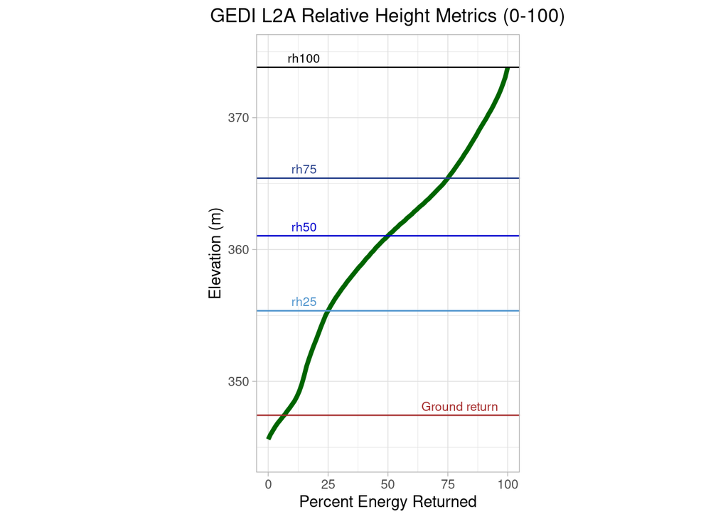

```r
ggplot(data=rh_t, aes(x=x_value, y=y_value)) +
  geom_line(color = "darkgreen", size = 1.5) + coord_fixed(ratio=4) +
  # add some horizontal lines such as ground elevation, highest reflecting surface height,
  # the relative height metrics at each quartile
  geom_hline(aes(yintercept=zElevation), color = "brown") +
  annotate(geom="text", label='Ground return', x=80, y=zElevation, vjust=-0.5, color ="brown", size=3)+
  geom_hline(aes(yintercept=rh_t['rh25','y_value']), color="steelblue3") +
  annotate(geom="text", label='rh25', x=15, y=rh_t['rh25','y_value'], vjust=-0.5, color ="steelblue3", size=3) +
  geom_hline(aes(yintercept=rh_t['rh50','y_value']), color="mediumblue") +
  annotate(geom="text", label='rh50', x=15, y=rh_t['rh50','y_value'], vjust=-0.5, color ="mediumblue", size=3) +
  geom_hline(aes(yintercept=rh_t['rh75','y_value']), color="royalblue4") +
  annotate(geom="text", label='rh75', x=15, y=rh_t['rh75','y_value'], vjust=-0.5, color ="royalblue4", size=3) +
  geom_hline(aes(yintercept=rh_t['rh100','y_value']), color="black") +
  annotate(geom="text", label='rh100', x=15, y=rh_t['rh100','y_value'], vjust=-0.5, color ="black", size=3) +
  ggtitle('GEDI L2A Relative Height Metrics (0-100)') + # title
  xlab('Percent Energy Returned') + # x-axis label
  ylab('Elevation (m)') + # y-axis label
  lims(y = c(rh_t$y_value[1] -1, rh_t$y_value[nrow(rh_t)] +1)) + # set y-axis scale
  theme_light() + # add a theme
  theme(plot.title = element_text(hjust = 0.5),# center the title
        aspect.ratio=5/3)  # set the plot ratio
```

## 8. Plot Beam Transects

This time a different orbit number and beam are chosen. The reason why we set a certain orbit number and a certain beam number is, we want to plot relative height metrics with elevation on the same line of GEDI pulses. Of course, you can change orbit number or beam number.

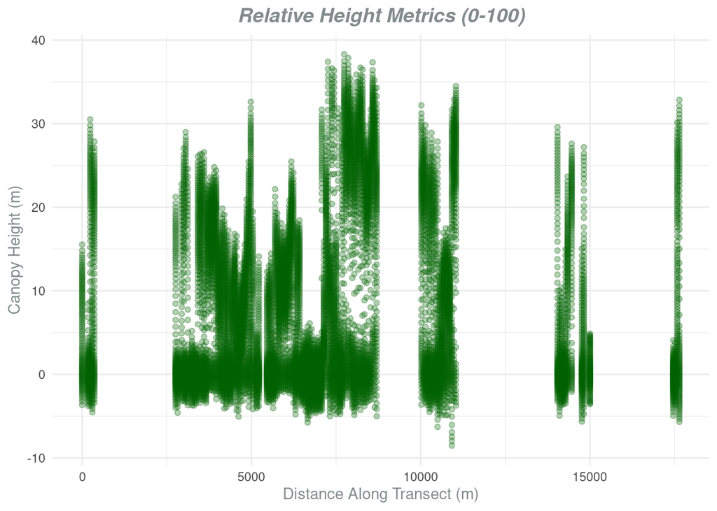

```r
shot_number_df <- st_set_geometry(level2A_forest_qf_1, NULL) %>%
  dplyr::filter(orbit_number == 5187 & beam == "BEAM0010") %>%
  dplyr::filter(row_number()==1 | row_number()==n()) %>%
  dplyr::select(shot_number)

# Subset the rows containing the shot numbers we chose
level2A_forest_qf_1_df_subset<- subset(as.data.frame(level2A_forest_qf_1),
                  shot_number > shot_number_df[1,1] & shot_number < shot_number_df[2,1])

# y-axis will be canopy height.
# we make a new data frame and add only canopy height data as a column
rh_df<- level2A_forest_qf_1_df_subset%>% dplyr::select(c(rh0:rh100))
# column and rows are changed (transpose)
rh_df_t <- data.table(rhs = c(t(rh_df)))

# we will plot the x-axis as distance.
# So, calculate the distance between pulses
distance <- as.numeric(diff(level2A_forest_qf_1_df_subset$shot_number))
distance <- c(0, distance)
distance <- cumsum(distance)
# and add the distance as a new column.
# Because GEDI Shots are spaced 60m apart, we multiply 60.
rh_df_t <- cbind(rh_df_t, distance_pulses= rep(distance*60, each = ncol(rh_df)))

# Plot canopy height vs. shot index as a scatter plot.
ggplot(rh_df_t , aes(x = distance_pulses, y = rhs)) +
  geom_point(color='darkgreen', alpha=0.3, size =1.5 ) +
  ggtitle('Relative Height Metrics (0-100)') +
  xlab('Distance Along Transect (m)') + ylab('Canopy Height (m)') +
  theme_minimal() +
  theme(
    plot.title = element_text(color="azure4", size=14, face="bold.italic",hjust = 0.5),
    axis.title.x = element_text(color="azure4"),
    axis.title.y = element_text(color="azure4"))
```

## 9. Plot RH Metrics Transects and Elevation

Now, we plot RH metrics adding elevation to get a better idea of the overall three-dimensional structure of this transect.

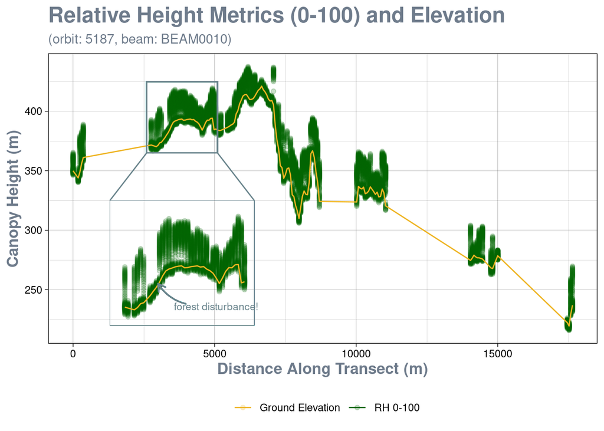

```r
# add elevation to rh 0-100 data frame
rh_df_elv <- rh_df + level2A_forest_qf_1_df_subset$elev_lowestmode
# column and rows are changed (transpose)
rh_df_elv_t <- data.table(rhs = c(t(rh_df_elv)))
# add x axis distance values
rh_df_elv_t <- cbind(rh_df_elv_t, distance_pulses= rep(distance*60, each = ncol(rh_df_elv)))

# create a data frame for elevation line plot
elv_df<- level2A_forest_qf_1_df_subset%>% dplyr::select(c(elev_lowestmode))
# add distance
elv_df$dist <- distance*60

# the main plot with all rh0-100 metrics with elevation
p_big <- ggplot(rh_df_elv_t , aes(x = distance_pulses, y = rhs)) +
            geom_point(aes(color='RH 0-100'), alpha=0.2, size =1.5 ) + #scatter plot
            geom_line(data=elv_df, aes(x=dist, y=elev_lowestmode, color="Ground Elevation" )) + #line plot
            scale_color_manual(values = c("Ground Elevation" = "goldenrod2", "RH 0-100" = "darkgreen")) + #add legend manually
            labs(title = "Relative Height Metrics (0-100) and Elevation", #title
                 subtitle ="(orbit: 5187, beam: BEAM0010)") + #subtitle
            xlab('Distance Along Transect (m)') + ylab('Canopy Height (m)') + #axis labels
            theme_linedraw() + #theme
            geom_rect(aes(xmin = 2600, xmax = 5100, ymin =365, ymax = 425), color = "lightblue4", alpha = 0) + #where we zoom in
            theme( # additional visualization elements like color, size of font...
              plot.title = element_text(color="lightsteelblue4", size=18, face="bold"),
              plot.subtitle =  element_text(color="lightsteelblue4", size=11),
              axis.title.x = element_text(color="lightsteelblue4", face="bold", size =13),
              axis.title.y = element_text(color="lightsteelblue4", face="bold", size = 13),
              legend.position="bottom",legend.box = "horizontal",
              legend.title = element_blank(),
              legend.background = element_rect(fill = "NA"))

# the zoomed small plot to analyze more exactly
p_small <- ggplot(rh_df_elv_t , aes(x = distance_pulses, y = rhs)) +
  geom_point(color='darkgreen', alpha=0.2, size =1.5 ) +
  geom_line(data=elv_df, aes(x=dist, y=elev_lowestmode), color="goldenrod2" ) +
  theme_minimal() +
  xlim (2600, 5100) +
  ylim (365, 425) +
  theme_void()

# please zoom the plot!
# now we visualize them
p_big +
  annotation_custom(ggplotGrob(p_small), xmin = 1300, xmax = 6400, ymin = 220, ymax = 325) +
  geom_rect(aes(xmin = 1300, xmax = 6400, ymin = 220, ymax = 325),
            color='lightblue4', linetype='solid', alpha=0, lwd = 0.1) +
  geom_path(aes(x,y,group=grp), color ="lightblue4",
            data=data.frame(x = c(1300,2600,6400,5100), y=c(325,365,325,365),grp=c(1,1,2,2)),
            linetype='solid') +
  geom_curve(
    aes(x = 4000, y = 238, xend = 3000, yend = 255),
    color = "lightblue4",
    curvature = -0.2,
    arrow = arrow(length = unit(0.03, "npc"))
  ) +
  annotate("text", x =5050, y=236, label = "forest disturbance!",color = "lightblue4", size = 3)
```

## 9. Statistics of GEDI-derived Elevation and Height Metrics (Level2A)

We will create a data frame consisting of NDVI and rh100.

1. create NDVI column

```r
# Extract raster value (NDVI) by points (GEDI shots)
disturbance_ndvi_df <- as.data.frame(raster::extract(ndvi_19, level2A_disturbance_qf_1))
# Rename the column name
colnames(disturbance_ndvi_df) <- "NDVI"
# change the NDVI value to float (To minimize the size of image, I downloaded the Sentinel-2
# Images as integer)
disturbance_ndvi_df$NDVI <-(disturbance_ndvi_df$NDVI)/10000
```

2. create rh100 column

```r
# add rh100 for statistical analysis
disturbance_ndvi_df$rh100 <- level2A_disturbance_qf_1$rh100
```

3. create shot_number column which will be removed later

```r
# we need this column only to delete outlier values.
disturbance_ndvi_df$shot_number <- level2A_disturbance_qf_1$shot_number
# (*) remove the values that matches with outliers from the original dataframe.
# This will be used later for the statistical analysis.
level2A_forest_qf_1_no_disturbance <- level2A_forest_qf_1[!(level2A_forest_qf_1$shot_number %in% disturbance_ndvi_df$shot_number),]
```

4. save outliers as dataframe

```r
# (why outliers here? some of pulses were edge of disturbance areas and show very high values.)
outlier_disturbance_ndvi_df <- disturbance_ndvi_df[disturbance_ndvi_df$rh100 %in% boxplot.stats(disturbance_ndvi_df$rh100)$out,]
```

5. destroy outliers from my precious dataframe

```r
# remove outliers and save it as dataframe
disturbance_ndvi_df <- disturbance_ndvi_df[!disturbance_ndvi_df$rh100 %in% boxplot.stats(disturbance_ndvi_df$rh100)$out,]
```

6. now remove the shot_number column from disturbance dataframe

```r
disturbance_ndvi_df <- dplyr::select(disturbance_ndvi_df, -shot_number)

head(disturbance_ndvi_df,10)
```

```
##      NDVI      rh100
## 1  0.5171 3.80999994
## 2  0.4951 3.92000008
## 3  0.4464 3.70000005
## 4  0.4864 3.57999992
## 5  0.5166 3.84999990
## 6  0.5405 3.80999994
## 7  0.5339 3.96000004
## 8  0.5271 3.92000008
## 9  0.5488 3.05999994
## 10 0.4511 3.84999990
```

```r
head(disturbance_ndvi_df,1)
```

```
##     NDVI      rh100
## 1 0.5171 3.80999994
```

```r
head(level2A_forest_qf_1_no_disturbance,1)
```

```
## Simple feature collection with 1 feature and 113 fields
## Geometry type: POINT
## Dimension:     XY
## Bounding box:  xmin: 9.07440424 ymin: 51.4670242 xmax: 9.07440424 ymax: 51.4670242
## Geodetic CRS:  WGS 84
##    orbit_number     beam       shot_number degrade_flag quality_flag delta_time
## 13         4958 BEAM0000 49580000200141000            0            1   57479230
##    sensitivity solar_elevation lat_lowestmode lon_lowestmode elev_highestreturn
## 13 0.923199296      1.50443447     51.4670242     9.07440424         351.265076
##    elev_lowestmode         rh0         rh1         rh2         rh3   rh4
## 13      327.110718 -2.13000011 -1.86000001 -1.57000005 -1.29999995 -1.12
##             rh5          rh6          rh7          rh8          rh9
## 13 -0.930000007 -0.819999993 -0.670000017 -0.560000002 -0.479999989
##            rh10         rh11         rh12         rh13          rh14
## 13 -0.370000005 -0.289999992 -0.180000007 -0.109999999 -0.0299999993
##            rh15        rh16        rh17        rh18        rh19        rh20
## 13 0.0700000003 0.140000001 0.219999999 0.330000013 0.409999996 0.519999981
##           rh21       rh22        rh23 rh24       rh25       rh26       rh27
## 13 0.629999995 0.74000001 0.850000024    1 1.14999998 1.34000003 1.57000005
##          rh28       rh29       rh30       rh31       rh32       rh33       rh34
## 13 1.89999998 2.27999997 2.69000006 3.05999994 3.47000003 4.07000017 5.11999989
##         rh35       rh36       rh37       rh38       rh39  rh40       rh41
## 13 5.9000001 8.10999966 9.78999996 10.5799999 10.9499998 11.29 11.6999998
##          rh42  rh43       rh44       rh45       rh46       rh47       rh48
## 13 12.1800003 12.71 13.1199999 13.5299997 13.9399996 14.3500004 14.8000002
##     rh49       rh50       rh51       rh52       rh53       rh54       rh55
## 13 15.25 15.6999998 16.0699997 16.4099998 16.7099991 16.9300003 17.1599998
##          rh56       rh57       rh58       rh59       rh60       rh61       rh62
## 13 17.3400002 17.5699997 17.7600002 17.9400005 18.1700001 18.3500004 18.5400009
##          rh63       rh64       rh65       rh66       rh67       rh68       rh69
## 13 18.7299995 18.8799992 19.0599995 19.2099991 19.3600006 19.5100002 19.6599998
##          rh70       rh71       rh72       rh73       rh74       rh75       rh76
## 13 19.8099995 19.9599991 20.1100006 20.2199993 20.3400002 20.4899998 20.6000004
##          rh77       rh78       rh79       rh80       rh81       rh82       rh83
## 13 20.7099991 20.8199997 20.9300003 21.0499992 21.2000008 21.3099995 21.4200001
##          rh84       rh85       rh86       rh87       rh88       rh89       rh90
## 13 21.5699997 21.6800003 21.7900009 21.9400005 22.0599995 22.1700001 22.3199997
##          rh91       rh92       rh93       rh94       rh95       rh96       rh97
## 13 22.4300003 22.5400009 22.6900005 22.7999992 22.9500008 23.1000004 23.2900009
##          rh98       rh99      rh100                      geometry
## 13 23.5100002 23.7800007 24.1499996 POINT (9.07440424 51.4670242)
```

```r
head(outlier_disturbance_ndvi_df,10)
```

```
##      NDVI      rh100       shot_number
## 16 0.4403 28.2299995 51870100200145247
## 19 0.4574 28.9799995 51870200200150330
## 20 0.5019 22.2000008 51870200200150340
## 30 0.5120 26.2099991 51870800200149964
## 31 0.5379 26.4400005 51870800200149965
## 41 0.3825 31.3099995 51870800200150081
## 42 0.3845 15.2399998 51870800200150082
```

Compute summary statistics (min, max, mean, and quartiles)

```r
summary(level2A_forest_qf_1_no_disturbance$rh100)
```

```
##    Min. 1st Qu.  Median    Mean 3rd Qu.    Max.
##  1.0800 17.6550 24.6350 23.0597 30.0125 64.1700
```

```r
# Even though we already deleted disturbance values, we see still very low values
# what is the lowest 10 % value? 6.278
quantile(level2A_forest_qf_1_no_disturbance$rh100, 0.1)
```

```
##        10%
## 6.27799997
```

```r
# here you can see all the values that are all low 10% of them.
sort(level2A_forest_qf_1_no_disturbance$rh100)[1:(length(level2A_forest_qf_1_no_disturbance$rh100)/10)]
```

```
##   [1] 1.08000004 1.41999996 1.72000003 1.86000001 2.08999991 2.30999994
##   [7] 2.34999990 2.65000010 2.76999998 2.83999991 2.95000005 3.02999997
##  [13] 3.09999990 3.14000010 3.17000008 3.22000003 3.25000000 3.25000000
##  [19] 3.25000000 3.28999996 3.31999993 3.31999993 3.32999992 3.32999992
##  [25] 3.32999992 3.44000006 3.48000002 3.48000002 3.50999999 3.50999999
##  [31] 3.58999991 3.58999991 3.58999991 3.58999991 3.58999991 3.58999991
##  [37] 3.58999991 3.61999989 3.63000011 3.63000011 3.66000009 3.66000009
##  [43] 3.70000005 3.70000005 3.70000005 3.70000005 3.70000005 3.70000005
##  [49] 3.70000005 3.73000002 3.74000001 3.76999998 3.76999998 3.77999997
##  [55] 3.77999997 3.80999994 3.80999994 3.81999993 3.81999993 3.84999990
##  [61] 3.84999990 3.84999990 3.84999990 3.89000010 3.93000007 3.96000004
##  [67] 4.00000000 4.00000000 4.03999996 4.07000017 4.07000017 4.07999992
##  [73] 4.07999992 4.07999992 4.07999992 4.15000010 4.15000010 4.15000010
##  [79] 4.17999983 4.17999983 4.17999983 4.19000006 4.21999979 4.23000002
##  [85] 4.23000002 4.26000023 4.26000023 4.26000023 4.28999996 4.34000015
##  [91] 4.36999989 4.38000011 4.38000011 4.40999985 4.44999981 4.51999998
##  [97] 4.55999994 4.59000015 4.59999990 4.63999987 4.67000008 4.67999983
## [103] 4.67999983 4.78000021 4.78999996 4.78999996 4.86000013 4.86000013
## [109] 4.86000013 4.86000013 4.86000013 4.86000013 4.90000010 4.90000010
## [115] 4.94000006 4.94000006 4.98000002 5.00000000 5.01000023 5.03999996
## [121] 5.09000015 5.09000015 5.11999989 5.15000010 5.19999981 5.26999998
## [127] 5.28000021 5.30000019 5.34000015 5.34999990 5.34999990 5.34999990
## [133] 5.38999987 5.38999987 5.42000008 5.48999977 5.53000021 5.53999996
## [139] 5.57999992 5.57999992 5.57999992 5.61000013 5.63999987 5.63999987
## [145] 5.65000010 5.65000010 5.69000006 5.69000006 5.71999979 5.71999979
## [151] 5.75000000 5.76000023 5.76000023 5.84000015 5.88000011 5.90999985
## [157] 5.94999981 5.98999977 6.01999998 6.01999998 6.05000019 6.05999994
## [163] 6.05999994 6.09000015 6.09000015 6.09999990 6.09999990 6.17000008
```

### why do we have a lot of low rh100 values?

- some of forest area data from copernicus land are misclassifed. Some areas are not forest.
- GEDI shots are on the edge of the forest data.
- forest disturbance data was not highly accurate
- other forest disturbances were not detected.
- disturbance data is based on medium of sentinel 2 images from May to October. Maybe some disturbance areas created in November. our GEDI data are from October to November.

Here you can see low rh100 GEDI data on the leaflet map

```r
level2A_forest_qf_1_no_disturbance$rh100_round <- round(level2A_forest_qf_1_no_disturbance$rh100, 1)
leaflet(data = (level2A_forest_qf_1_no_disturbance %>% filter(rh100 < 10))) %>%
  addProviderTiles(providers$Esri.WorldImagery) %>% #OpenStreetMap
  addMarkers(~lon_lowestmode, ~lat_lowestmode,
                      label =  ~as.character(rh100_round),
                      labelOptions = labelOptions(noHide = T, direction = 'top', textOnly = T, textsize = "15px"))
```

[interactive chart not shown]

### Create function of plotting correlation graphs and compare the results produced by selecting different sample size.

Depending on the size of samples from forest disturbance GEDI data and no-disturbance GEDI data, the correlation is different.

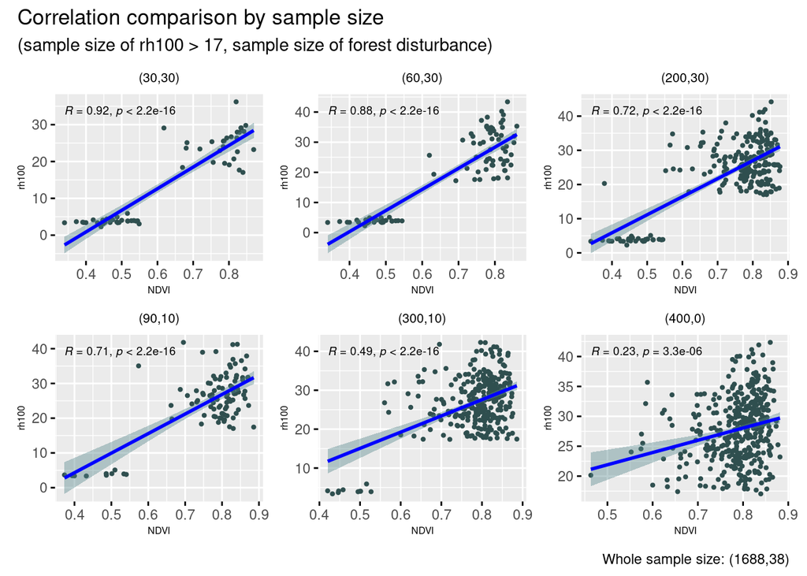

```r
show_cor <- function(sample_n_forest, sample_n_disturbance) {
  forest_sample <- level2A_forest_qf_1_no_disturbance[sample(which(level2A_forest_qf_1_no_disturbance$rh100 >17), sample_n_forest), ]
  extract_df2 <- as.data.frame(raster::extract(ndvi_19, forest_sample))
  colnames(extract_df2) <- "NDVI"
  extract_df2$NDVI <-(extract_df2$NDVI)/10000
  extract_df2$rh100 <- forest_sample$rh100
  extract_df2 <- extract_df2[!extract_df2$rh100 %in% boxplot.stats(extract_df2$rh100)$out,]
  disturbance_ndvi_sample <- sample_n(disturbance_ndvi_df, sample_n_disturbance)
  final_extract_df <- rbind(disturbance_ndvi_sample,extract_df2)
  p_title = paste0("(", sample_n_forest, ",",sample_n_disturbance,")")
  p <- ggscatter(final_extract_df, x = "NDVI", y = "rh100",
                 color = "darkslategrey",
                 fill = "darkslategrey",
                 repel = TRUE,
            add = "reg.line", # Add regression line
            conf.int = TRUE,  # Add confidence interval
            add.params = list(color = "blue",
                              fill = "cadetblue4"),
            size = 0.8,
            cor.coef = TRUE,
            cor.coef.size = 2.5,
            cor.coeff.args = list(method = "pearson"),
            xlab = "NDVI", ylab = "rh100", title =  p_title,
            ggtheme = theme(plot.title = element_text(hjust = 0.5, size=8),
                            axis.title.x  = element_text(size = 6),
                            axis.title.y  = element_text(size = 6),
                            ))

  return(p)
}
library(patchwork)
p1 <- show_cor(30,30)
p2 <- show_cor(60,30)
p3 <- show_cor(200,30)
p4 <- show_cor(90,10)
p5 <- show_cor(300,10)
p6 <- show_cor(400,0)

(p1 + p2 +p3+ p4+ p5+p6) + plot_layout(ncol = 3, nrow = 2,)+ plot_annotation(
  title = 'Correlation comparison by sample size',
  subtitle = "(sample size of rh100 > 17, sample size of forest disturbance)",
  caption = paste0("Whole sample size: (" , nrow(level2A_forest_qf_1_no_disturbance), ",",nrow(disturbance_ndvi_df),")")
)
```